# Clustering and PCA

## Part Two: PCA

Perform a principal components analysis on this dataset, and create TWO figures from your PCA. Each figure should have a brief explanation as a bullet below it. For each figure, your should be labeled to include information about how much variation the given PC explains in the data.

```r
## Code to perform PCA goes here

olives %>%
  ##remove non-numeric variables
  select(-region, -area) %>%
  ##scale the data to ensure stochasticity and ensure a matrix is the output
  scale() %>%
  prcomp() -> olives_pca
```

1. But first, use code to answer this question! Intepret how variables in the initial dataset **load** on the PCs by examining, you guessed it, the loadings. In the bullets below, state which SINGLE variable load most strongly on PC1 and PC2 each, and which SINGLE variable loads most weakly on PC1 and PC2.

```r
## Code to examine loadings goes here
olives_pca$rotation
```

```
##                     PC1         PC2         PC3         PC4         PC5
## palmitic     0.46074351  0.04958406 -0.11445834 -0.28043124  0.53473943
## palmitoleic  0.45022576  0.24090732 -0.14260264 -0.21182252  0.13841908
## stearic     -0.09864471 -0.25837844 -0.80215910  0.47082168  0.21340068
## oleic       -0.49417494 -0.15866175  0.08011486 -0.20010742 -0.01552215
## linoleic     0.36569539  0.34339930  0.08747773  0.51249093 -0.40127538
## linolenic    0.21898707 -0.60483760  0.19103316 -0.09881321  0.12507081
## arachidic    0.22830362 -0.44719396  0.42664494  0.48165441  0.14659527
## eicosenoic   0.31186781 -0.40476916 -0.30085585 -0.33222211 -0.67153429
##                     PC6         PC7        PC8
## palmitic    -0.07699892 -0.52540418 0.35438653
## palmitoleic -0.16728954  0.78680816 0.08856309
## stearic      0.03064009  0.07722664 0.07703841
## oleic       -0.11309403  0.18074878 0.79903372
## linoleic     0.30497855 -0.07768793 0.46687817
## linolenic    0.69784174  0.19096065 0.02943890
## arachidic   -0.55365142  0.06527504 0.03996552
## eicosenoic  -0.25657629 -0.13959613 0.04168750
```

```r
##oleic acid loads strongly to PCA 1, which means it contributes the most to the information
##extra PCA notes:
##if arrows are pointed 180 degrees apart, they are oppositely-related (contributing opposite info)
##if arrows are pointed 90 degrees apart, they are related orthogonally so they might have one variable in common
```

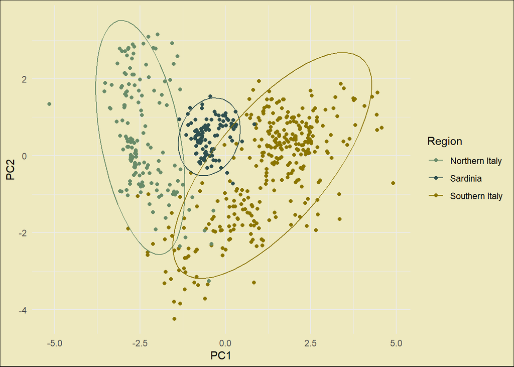

```r
##Code to make this figure goes here
as_tibble(olives_pca$x) %>%
  mutate(region = olives$region) %>%
  ggplot(aes(x = PC1, y = PC2, color = region)) +
  geom_point() +
  scale_color_manual(name = "Region", values =  c("darkseagreen4", "darkslategrey", "gold4")) +
  ##the argument stat_ellipse forms an ellipse around whatever is colored in the plot. In this case, that's region.
  stat_ellipse() +
  xlab("PC1") +
  ylab("PC2") +
  theme_minimal() +
  ##must use element_rect() with plot.background!
  theme(plot.background = element_rect(fill = "lemonchiffon2"))
```

```r
##PCA uses linear algebra to create a version with transformed axes to examine variation among portions of the dataset
```

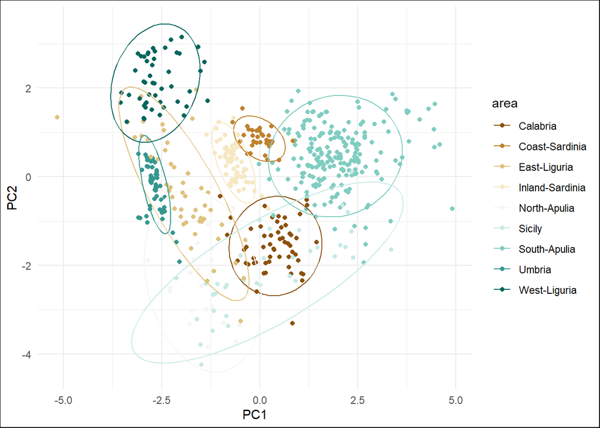

```r
as_tibble(olives_pca$x) %>%
  mutate(area = olives$area) %>%
  ##for scatterplot, x and y are PCAs
  ggplot(aes(x = PC1, y = PC2, color = area)) +
  geom_point() +
  ##easier to use a brewer palette here
  scale_color_brewer(palette = "BrBG") +
  stat_ellipse() +
  theme_minimal() +
  ##only fill that works for the background here is white
  theme(plot.background = element_rect(fill = "white"))
```

```r
##Sardinia's are next to each other
```

## BONUS QUESTION 1

Make a figure of the loadings on PC1 and PC2 in the space below. Make sure it is as legible as possible! No explanation needed, just make a plot!

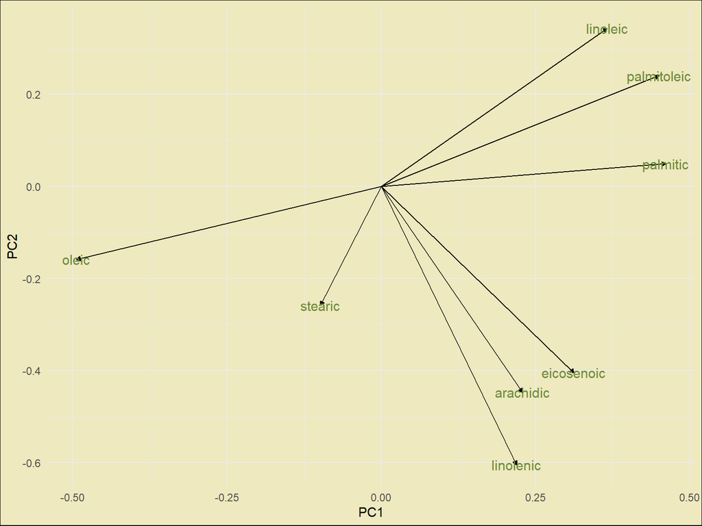

```r
## Bonus loadings plot

##Wrangling (slide 13 is helpful for this)
##convert to data frame and then tibble because it starts out as a matrix
olives_pca$rotation %>%
  as.data.frame() %>%
  rownames_to_column("quantity") %>%
  as_tibble() -> olives_pca_loadings

##create arrow specifics
dr_spielman_arrow <- grid::arrow(length = unit(0.05, "inches"), type = "closed")

##create PC1 and PC2 loadings figure
olives_pca_loadings %>%
  ggplot(aes(x = PC1, y = PC2)) +
  ##specify arrow in geom_segment
  geom_segment(x = 0,
               y = 0,
               arrow = dr_spielman_arrow,
               aes(xend = PC1, yend = PC2)) +
  ##play around with text to make it suitable
  geom_text(aes(label = quantity),
                 size = 4, color = "darkolivegreen4") +
  theme_minimal() +
  theme(plot.background = element_rect(fill = "lemonchiffon2"))
```

```r
##may have to set xlim and ylim depending on the output for future plots
```

## BONUS QUESTION 2

Perform a k-means clustering with *k=3* on the PCs to examine whether olive *regions* cluster together. **You must include a clear explanation (1-3 sentences) to receive ANY CREDIT AT ALL for this bonus.**

```r
## Bonus clustering
```